# HW7 Decision Tree

### **Competitive Auctions on eBay.com.**

The file eBayAuctions.csv contains information on 1972 auctions that transacted on eBay.com during May–June 2004. The goal is to use these data to build a model that will classify auctions as competitive or noncompetitive. A competitive auction is defined as an auction with at least two bids placed on the item auctioned. The data include variables that describe the item (auction category), the seller (his/her eBay rating), and the auction terms that the seller selected (auction duration, opening price, currency, day-of-week of auction close). In addition, we have the price at which the auction closed. The task is to predict whether or not the auction will be competitive.

### **Data Preprocessing.**

Convert variable Duration into a categorical variable. Split the data into training (60%) and validation (40%) datasets.

**a. Fit a classification tree using all predictors, using the best-pruned tree. To avoid overfitting, set the minimum number of records in a terminal node to 50 (in R: minbucket = 50). Also, set the maximum number of levels to be displayed at seven (in R: maxdepth = 7).Write down the results in terms of rules. (Note: If you had to slightly reduce the number of predictors due to software limitations, or for clarity of presentation, which would be a good variable to choose?)**

```r
library(rpart)
library(rpart.plot)

# read in dataset
ebay.df <- read.csv("eBayAuctions.csv")
View(ebay.df)
ebay.df$Competitive. <- as.factor(ebay.df$Competitive.)

#data partition (train = 60%, valid = 40%)
set.seed(1)
train.id <- sample(1:nrow(ebay.df), nrow(ebay.df)*0.6)
train.df <- ebay.df[train.id, ]
valid.df <- ebay.df[-train.id, ]
cat("Total rows:", nrow(ebay.df),
    "\nTrain rows:", nrow(train.df),
    "\nValid rows:", nrow(valid.df))
```

```
Total rows: 1972
Train rows: 1183
Valid rows: 789
```

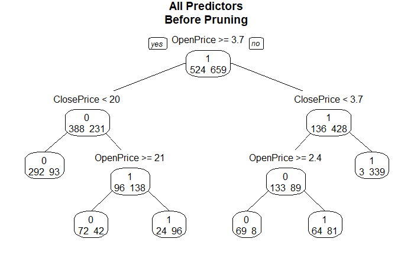

```r
# Fit classification tree (using all predictors)
full.ct <- rpart(Competitive.~., data=train.df, method="class",
                 cp=0.00001, maxdepth=7, minbucket=50, xval=5)
prp(full.ct, type=1, extra=1, split.font=1, varlen=-10,
    main="All Predictors\nBefore Pruning")
```

```r
# Prune the tree
printcp(full.ct)
```

```
Classification tree:
rpart(formula = Competitive. ~ ., data = train.df, method = "class",
    cp = 1e-05, maxdepth = 7, minbucket = 50, xval = 5)

Variables actually used in tree construction:
[1] ClosePrice OpenPrice

Root node error: 524/1183 = 0.44294

n= 1183

        CP nsplit rel error  xerror     xstd
1 0.299618      0   1.00000 1.00000 0.032605
2 0.083969      1   0.70038 0.74237 0.030836
3 0.080153      2   0.61641 0.61069 0.029158
4 0.057252      3   0.53626 0.56489 0.028430
5 0.032443      4   0.47901 0.49046 0.027068
6 0.000010      5   0.44656 0.47710 0.026797
```

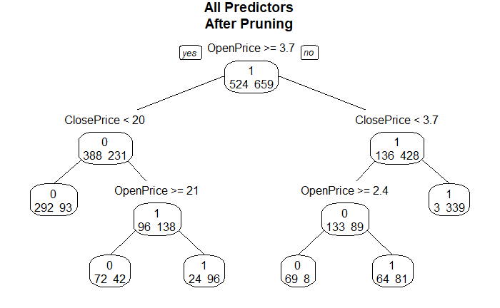

```r
full.pruned.ct <- prune(full.ct, cp=full.ct$cptable[which.min(full.ct$cptable[,"xerror"]),"CP"])
prp(full.pruned.ct, type=1, extra=1, split.font=1, varlen=-10,
    main="All Predictors\nAfter Pruning")
```

**b. Is this model practical for predicting the outcome of a new auction?**

This model is not practical for predicting the outcome of a new auction, because we don’t know the ClosePrice of it.

**c. Describe the interesting and uninteresting information that these rules provide.**

The only predictors used in this model are the OpenPrice and ClosePrice, which certainly has a correlation with the Competitive/Non-competitive of the auction. However, there is not much interesting information from the result, since we can easily infer that more price difference (ClosePrice - OpenPrice) means higher possibility for Competitive auction, which is similar (but not exactly same) to use only the price difference for the classification.

**d. Fit another classification tree (using the best-pruned tree, with a minimum number of records per terminal node = 50 and maximum allowed number of displayed levels = 7), this time only with predictors that can be used for predicting the outcome of a new auction. Describe the resulting tree in terms of rules. Make sure to report the smallest set of rules required for classification.**

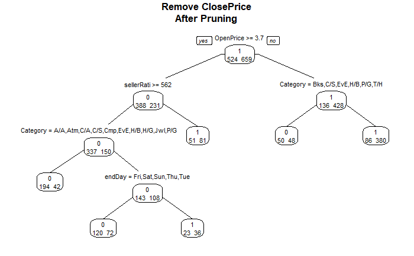

```r
# Fit classification tree (remove ClosePrice)
new.ct <- rpart(Competitive.~.-ClosePrice, data=train.df, method="class",
                 cp=0.00001, maxdepth=7, minbucket=50, xval=5)
prp(new.ct, type=1, extra=1, split.font=1, varlen=-10,
    main="Remove ClosePrice\nAfter Pruning")
```

From the plot we know there are 6 different rules generated by this model:

1. IF (OpenPrice >= 3.7) AND (sellerRating >= 562) AND (Category = A/A, Atm, C/A, C/S, Cmp, EvE, H/B, H/G, Jwl, P/G) THEN Class = 0
2. IF (OpenPrice >= 3.7) AND (sellerRating >= 562) AND (Category != A/A, Atm, C/A, C/S, Cmp, EvE, H/B, H/G, Jwl, P/G) AND (endDay = Fri, Sat, Sun, Thu, Tue) THEN Class = 0
3. IF (OpenPrice >= 3.7) AND (sellerRating >= 562) AND (Category != A/A, Atm, C/A, C/S, Cmp, EvE, H/B, H/G, Jwl, P/G) AND (endDay != Fri, Sat, Sun, Thu, Tue) THEN Class = 1
4. IF (OpenPrice >= 3.7) AND (sellerRating < 562) THEN Class = 1
5. IF (OpenPrice < 3.7) AND (Category = Bks, C/S, EvE, H/B, P/G, T/H) THEN Class = 0
6. IF (OpenPrice < 3.7) AND (Category != Bks, C/S, EvE, H/B, P/G, T/H) THEN Class = 1

Since there is not repetition of variables in a given rule, the above is the smallest set of rules for classification.

**e. Plot the resulting tree on a scatter plot: Use the two axes for the two best (quantitative) predictors. Each auction will appear as a point, with coordinates corresponding to its values on those two predictors. Use different colors or symbols to separate competitive and noncompetitive auctions. Draw lines (you can sketch these by hand or use R) at the values that create splits. Does this splitting seem reasonable with respect to the meaning of the two predictors? Does it seem to do a good job of separating the two classes?**

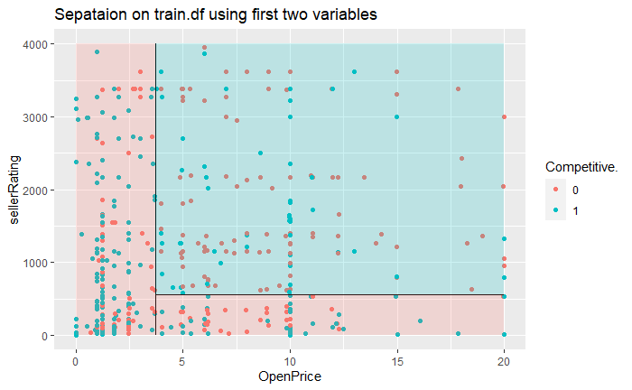

```r
library(ggplot2)

qplot(x=OpenPrice, xlim=c(0, 20), xlab="OpenPrice",
    y=sellerRating, ylim=c(0, 4000), ylab="sellerRating",
    data=train.df, color=Competitive.) +
  geom_segment(aes(x=3.7, xend=3.7, y=0, yend=4000), color="black") +
  geom_segment(aes(x=3.7, xend=20, y=562, yend=562), color="black") +
  annotate("rect", xmin=3.7, xmax=20, ymin=0, ymax=562, fill="#F8766D", alpha=0.2) +
  annotate("rect", xmin=3.7, xmax=20, ymin=562, ymax=4000, fill="#00BFC4", alpha=0.2) +
  annotate("rect", xmin=0, xmax=3.7, ymin=0, ymax=4000, fill="#F8766D", alpha=0.2) +
  ggtitle("Sepataion on train.df using first two variables")
```

**f. Examine the lift chart and the confusion matrix for the tree. What can you say about the predictive performance of this model?**

```r
library(caret)

## confusion matrix
new.train.pred <- predict(new.ct, train.df, type="class")
confusionMatrix(train.df$Competitive., new.train.pred) # train
```

```
Confusion Matrix and Statistics

          Reference
Prediction   0   1
         0 364 160
         1 162 497

               Accuracy : 0.7278
                 95% CI : (0.7015, 0.753)
    No Information Rate : 0.5554
    P-Value [Acc > NIR] : <2e-16

                  Kappa : 0.4487

 Mcnemar's Test P-Value : 0.9556

            Sensitivity : 0.6920
            Specificity : 0.7565
         Pos Pred Value : 0.6947
         Neg Pred Value : 0.7542
             Prevalence : 0.4446
         Detection Rate : 0.3077
   Detection Prevalence : 0.4429
      Balanced Accuracy : 0.7242

       'Positive' Class : 0
```

```r
new.valid.pred <- predict(new.ct, valid.df, type="class")
confusionMatrix(valid.df$Competitive., new.valid.pred) # valid
```

```
Confusion Matrix and Statistics

          Reference
Prediction   0   1
         0 241 141
         1 103 304

               Accuracy : 0.6907
                 95% CI : (0.6572, 0.7229)
    No Information Rate : 0.564
    P-Value [Acc > NIR] : 1.883e-13

                  Kappa : 0.379

 Mcnemar's Test P-Value : 0.01785

            Sensitivity : 0.7006
            Specificity : 0.6831
         Pos Pred Value : 0.6309
         Neg Pred Value : 0.7469
             Prevalence : 0.4360
         Detection Rate : 0.3054
   Detection Prevalence : 0.4842
      Balanced Accuracy : 0.6919

       'Positive' Class : 0
```

From the results above we know the performance of this model is not ideal on both training and valid dataset. The accuracy is 73% for train, 69% for valid, and the sensitivity and specificity are all near 70%, so the model does not overfits the data much, but it fails to generalize the pattern that are crucial for this classification.

**g. Based on this last tree, what can you conclude from these data about the chances of an auction obtaining at least two bids and its relationship to the auction settings set by the seller (duration, opening price, ending day, currency)? What would you recommend for a seller as the strategy that will most likely lead to a competitive auction?**